# Section 7.3: Languages in NP

# Motivating Example: Euler Paths and Hamilton Paths

## Euler Paths

- An *Euler path* in a graph $G$ is a path that visits every *edge* exactly once.

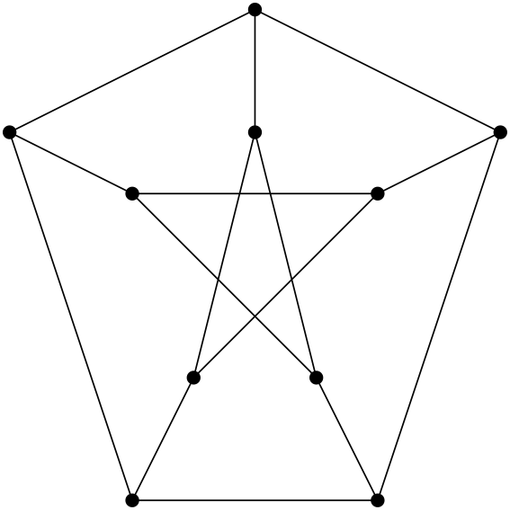

## $\mathit{EULER} \in \text{P}$

Let $\mathit{EULER} = \{ \langle G \rangle \mid G \text{ has an Euler path}\}$

- We can decide if a graph has an Euler path by computing the degrees of each vertex.
- If there are 0 or 2 vertices of odd degree, then it does.
- If not, then it doesn’t.

So $\mathit{EULER}$ is decidable in *polynomial time*.

## Hamilton Paths

- A *Hamilton path* in a graph $G$ is a path that visits every *vertex* exactly once.

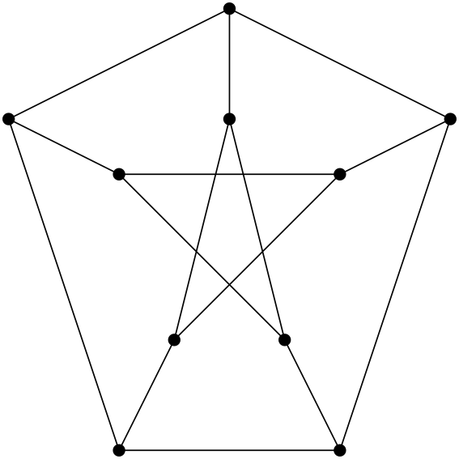

## Checking versus finding

Let $\mathit{HAMPATH} = \{ \langle G \rangle \mid G \text{ has a Hamilton path}\}$

- Given a sequence of vertices, we can *check* to see if it is a Hamilton path in polynomial time.
- However, there is *no known polynomial-time algorithm* for determining whether a Hamilton path exists.

If we allow for a *nondeterministic TM*, we could just try all $n!$ possible sequences of vertices at once, and then we could decide $\mathit{HAMPATH}$ in polynomial time. But nobody knows how to do this deterministically.

# The class $\text{NP}$

## Recall

The class $\text{P}$ contains all problems (i.e., languages) that are *solvable* (i.e., decidable) in polynomial time.
$$\scriptsize \text{P} =
\{ A \mid \text{ there is a polynomial-time TM decider } M \text{ with }
L(M) = A \}$$

- Here $M$ has to be a *deterministic* TM.
- $\text{P}$ are the “easy” problems, computationally.

## $\text{NP}$

- The class $\text{NP}$ is the set of all languages that are decidable in polynomial time by a *nondeterministic* TM.
- Alternatively, $\text{NP}$ contains all problems whose solutions can be *verified* in polynomial time, by a deterministic TM.
  - In other words, given a possible solution, there is a deterministic TM that can check if the the solution is correct, in polynomial time.

## Verifiers

A *verifier* of a language $A$ is a deterministic TM $V$ such that
$$A = \{w \mid V \text{ accepts } \langle w, c \rangle \text{ for some
string } c\}$$

- $c$ is called a *certificate*.
- Example: $A = \mathit{HAMPATH}$, $w$ is a graph we’re not sure about, $c$ is a list of vertices in $w$.
  - We can check to see if $c$ is a Hamilton path in polynomial time.
  - If $c$ is a Hamilton path, then $w \in A$.

## Two characterizations of $\text{NP}$

- $\text{NP}$ is the set of all languages that are decidable in polynomial time by a *nondeterministic* TM.
- $\text{NP}$ is the set of all languages having polynomial-time (*deterministic*) verifiers.

These are equivalent.

- Given a verifier, just nondeterministically try all the $c$’s.
- Given a nondeterministic TM decider, the certificates are the different nondterministic branches to try.

## $\text{P} \subseteq \text{NP}$

- If a language can be decided in polynomial time by a determinitstic TM, then it can be decided in polynomial time by a nondeterministic TM.
- So $\text{P} \subseteq \text{NP}$
- It is *unknown* whether there are any languages in $\text{NP}$ that are not in $\text{P}$.

# Examples of Languages in $\text{NP}$

## $\mathit{CLIQUE}$

- A *clique* in a graph is a subset of vertices that are all connected to each other.
- $\mathit{CLIQUE} = \{\langle G, k \rangle \mid G \text{ has a clique with } k \text{ vertices} \}$

We can verify $\mathit{CLIQUE}$ in polynomial time. On input $\langle \langle G,k\rangle, c\rangle$,

1. Test whether $c$ is a subgraph with $k$ vertices. If so,
2. test whether all the vertices of $c$ are adjacent. If so, accept. If not, reject.

Running time: $O(nk)+O(k^2) = O(n^2)$. So $\mathit{CLIQUE}\in \text{NP}$.

## $\mathit{SUBSET\text{-}SUM}$

- $\mathit{SUBSET\text{-}SUM} = \{\langle S,t\rangle \mid S \text{ has a subset that sums to } t \}$, where $S$ is a set of natural numbers.

Polynomial time verifier: On input $\langle \langle S,t\rangle, c\rangle$,

1. Test whether $c$ is a subset of $S$, if so,
2. test whether the elements of $c$ add up to $S$. If so, accept. If not, reject.

The length of $\langle S,t\rangle$ is polynomially equivalent to the number $n$ of elements in $S$. ($O(n\log n)$) The first step is at most $O(n^2)$. The second step is $O(n\log n)$.